TODO: Create many scenarios to try and test. Figure out whats next. Any uncertain linkages?

# How to build a model

### Mangrove response to climate change and other anthropogenic threats

Taking a ‘one model to rule them all approach’ vs. multiple, individual models for different scenarios. We agree there should be only one model structure. If we think the model structure isn’t right though, we can test and compare other variations.

Aim is to build one model that performs as expected under different scenarios.

Then we can map likelihood of increase or decrease in mangrove extent, given different drivers

Steps are to:

1. Build and visualise the conceptual model
2. Perturb drivers to examine expected responses of mangroves under different scenarios
3. If responses are not expected, re-work the conceptual model and do step 2
4. Map likelihood of mangroves increasing or decreasing given different geomorphologies and drivers
5. Validate with GMW data (if possible)

### 1. Build and visualise conceptual model

Variables are in white and drivers are in grey. Red arrows indicate negative effect, black arrows indicate positive effect.

```
## [1] TRUE
```

```
## [1] 1
```

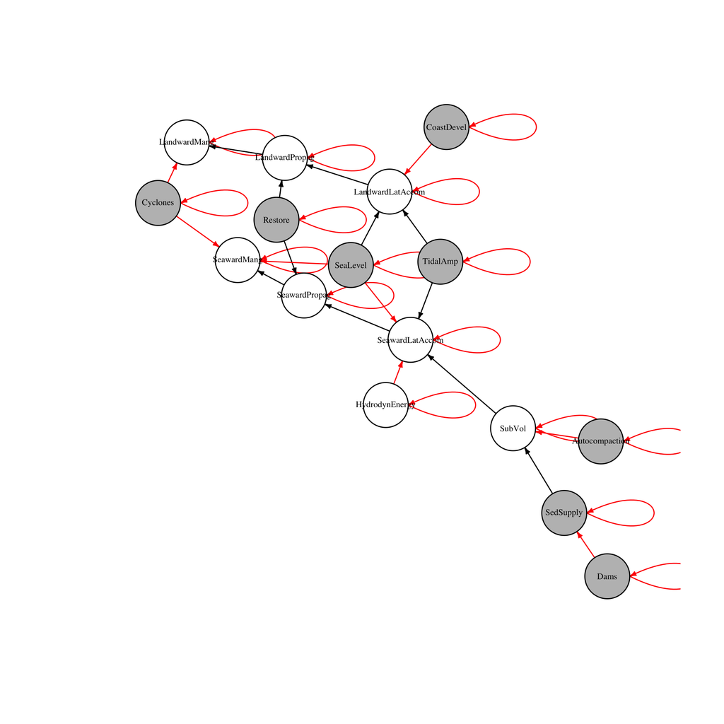

**TODO: Would like to have an ‘organic matter’ variable that can have a positive effect on substrate volume (SubVol), and is positively influenced by Seaward and Landward mangroves. Substrate volume should also perhaps be influenced by hydroperiod? High frequency of tidal inundation means sediment and organic matter less able to settle to the bottom?

*Note, only way to get a stable model was to enforce self-limitation on all variables.

#### Scenario 1: High sediment supply

Expect Seaward of mangroves to increase

```
##   Autocompaction       CoastDevel         Cyclones             Dams
##                0                0                0                0
##   HydrodynEnergy LandwardLatAccom     LandwardMang   LandwardPropag
##                0                0                0                0
##          Restore         SeaLevel  SeawardLatAccom      SeawardMang
##                0                0                1                1
##    SeawardPropag        SedSupply           SubVol         TidalAmp
##                1                1                1                0
```

So the net feedLandward is for mangrove increase.

#### Scenario 2: High sediment supply and sea-level fall (e.g., during drought)

Expect Seaward mangroves to increase (progradation) and mangrove dieLandward in the Landward.

```
##   Autocompaction       CoastDevel         Cyclones             Dams
##                0                0                0                0
##   HydrodynEnergy LandwardLatAccom     LandwardMang   LandwardPropag
##                0               -1               -1               -1
##          Restore         SeaLevel  SeawardLatAccom      SeawardMang
##                0               -1                2                3
##    SeawardPropag        SedSupply           SubVol         TidalAmp
##                2                1                1                0
```

Seaward mangroves increase and Landward die.

#### Scenario 3: High sediment supply and sea-level rise

```
##   Autocompaction       CoastDevel         Cyclones             Dams
##                0                0                0                0
##   HydrodynEnergy LandwardLatAccom     LandwardMang   LandwardPropag
##                0                1                1                1
##          Restore         SeaLevel  SeawardLatAccom      SeawardMang
##                0                1                0               -1
##    SeawardPropag        SedSupply           SubVol         TidalAmp
##                0                1                1                0
```

Landward mangroves increase, but Seaward decrease. Not what we would expect

#### Scenario 4: Sea-level rise

Expect landward mangroves to increase

```
##   Autocompaction       CoastDevel         Cyclones             Dams
##                0                0                0                0
##   HydrodynEnergy LandwardLatAccom     LandwardMang   LandwardPropag
##                0                1                1                1
##          Restore         SeaLevel  SeawardLatAccom      SeawardMang
##                0                1               -1               -2
##    SeawardPropag        SedSupply           SubVol         TidalAmp
##               -1                0                0                0
```

Landward mangroves increase as expected. Seaward mangroves decrease, as expected.

### Simulate scenarios and compare outcomes

The above assumed that the weights of all processes are equal. We can additionally do simulations where we randomly vary the weights. Not implemented here, but we should also consider adding constraints where we say weight of one path is greater than an alternate path. Will need your help deciding on those constraints though.

Below graph shows proportion of positive change predicted across 1000 models with randomized weights.

[figure not shown]

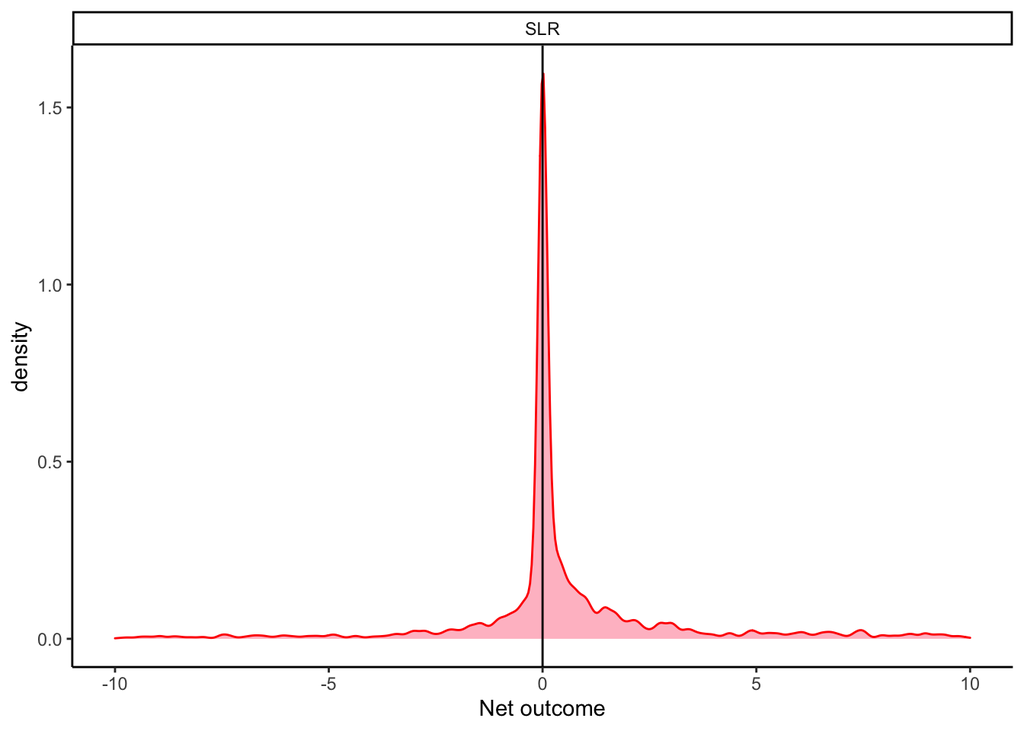

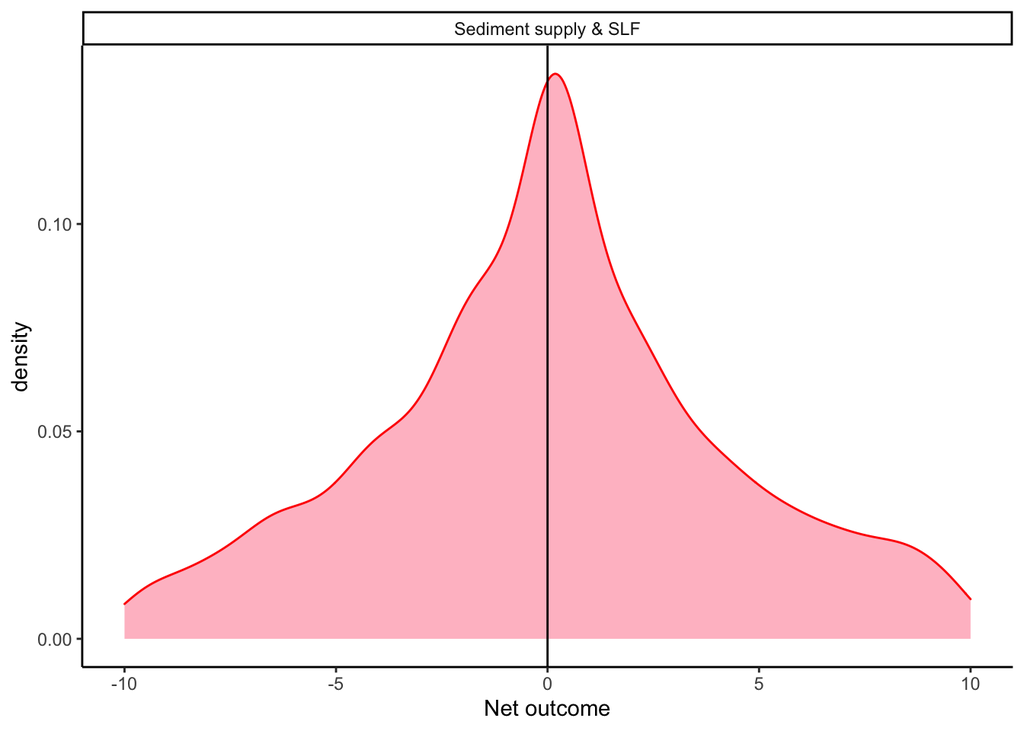